# Risk Factor Analysis

## Outcome Variable

**Outcome Variable:** stunted

## Predictor Variables

**Intervention Variable:** tr

**Adjustment Set:**

unadjusted

## Stratifying Variables

The analysis was stratified on these variable(s):

- agecat
- studyid
- country
- intXpredexfd6

## Data Summary

| agecat | studyid | country | intXpredexfd6 | stunted | n_cell | n |
| --- | --- | --- | --- | --- | --- | --- |
| Birth | ki1000304b-SAS-CompFeed | INDIA | 0_Birth | 0 | 1 | 1 |
| Birth | ki1000304b-SAS-CompFeed | INDIA | 0_Birth | 1 | 0 | 1 |
| Birth | ki1000304b-SAS-CompFeed | INDIA | 1_Birth | 0 | 32 | 36 |
| Birth | ki1000304b-SAS-CompFeed | INDIA | 1_Birth | 1 | 4 | 36 |
| Birth | kiGH5241-JiVitA-3 | BANGLADESH | 0_Birth | 0 | 4950 | 7972 |
| Birth | kiGH5241-JiVitA-3 | BANGLADESH | 0_Birth | 1 | 3022 | 7972 |
| Birth | kiGH5241-JiVitA-3 | BANGLADESH | 1_Birth | 0 | 21130 | 30192 |
| Birth | kiGH5241-JiVitA-3 | BANGLADESH | 1_Birth | 1 | 9062 | 30192 |
| Birth | kiGH5241-JiVitA-4 | BANGLADESH | 0_Birth | 0 | 182 | 296 |
| Birth | kiGH5241-JiVitA-4 | BANGLADESH | 0_Birth | 1 | 114 | 296 |
| Birth | kiGH5241-JiVitA-4 | BANGLADESH | 1_Birth | 0 | 878 | 1238 |
| Birth | kiGH5241-JiVitA-4 | BANGLADESH | 1_Birth | 1 | 360 | 1238 |
| 6 months | iLiNS_DYADM_LNS | MALAWI | 0_6 months | 0 | 2 | 3 |
| 6 months | iLiNS_DYADM_LNS | MALAWI | 0_6 months | 1 | 1 | 3 |
| 6 months | iLiNS_DYADM_LNS | MALAWI | 1_6 months | 0 | 44 | 61 |
| 6 months | iLiNS_DYADM_LNS | MALAWI | 1_6 months | 1 | 17 | 61 |
| 6 months | ki1000304b-SAS-CompFeed | INDIA | 0_6 months | 0 | 11 | 14 |
| 6 months | ki1000304b-SAS-CompFeed | INDIA | 0_6 months | 1 | 3 | 14 |
| 6 months | ki1000304b-SAS-CompFeed | INDIA | 1_6 months | 0 | 181 | 257 |
| 6 months | ki1000304b-SAS-CompFeed | INDIA | 1_6 months | 1 | 76 | 257 |
| 6 months | ki1000304b-SAS-FoodSuppl | INDIA | 0_6 months | 0 | 84 | 160 |
| 6 months | ki1000304b-SAS-FoodSuppl | INDIA | 0_6 months | 1 | 76 | 160 |
| 6 months | ki1017093b-PROVIDE | BANGLADESH | 0_6 months | 0 | 14 | 18 |
| 6 months | ki1017093b-PROVIDE | BANGLADESH | 0_6 months | 1 | 4 | 18 |
| 6 months | ki1017093b-PROVIDE | BANGLADESH | 1_6 months | 0 | 22 | 28 |
| 6 months | ki1017093b-PROVIDE | BANGLADESH | 1_6 months | 1 | 6 | 28 |
| 6 months | ki1148112-iLiNS-DOSE | MALAWI | 0_6 months | 0 | 110 | 161 |
| 6 months | ki1148112-iLiNS-DOSE | MALAWI | 0_6 months | 1 | 51 | 161 |
| 6 months | ki1148112-iLiNS-DOSE | MALAWI | 1_6 months | 0 | 727 | 1014 |
| 6 months | ki1148112-iLiNS-DOSE | MALAWI | 1_6 months | 1 | 287 | 1014 |
| 6 months | ki1148112-iLiNS-DYAD-M | MALAWI | 0_6 months | 0 | 2 | 3 |
| 6 months | ki1148112-iLiNS-DYAD-M | MALAWI | 0_6 months | 1 | 1 | 3 |
| 6 months | ki1148112-iLiNS-DYAD-M | MALAWI | 1_6 months | 0 | 70 | 94 |
| 6 months | ki1148112-iLiNS-DYAD-M | MALAWI | 1_6 months | 1 | 24 | 94 |
| 6 months | ki1148112-LCNI-5 | MALAWI | 0_6 months | 0 | 145 | 225 |
| 6 months | ki1148112-LCNI-5 | MALAWI | 0_6 months | 1 | 80 | 225 |
| 6 months | ki1148112-LCNI-5 | MALAWI | 1_6 months | 0 | 30 | 47 |
| 6 months | ki1148112-LCNI-5 | MALAWI | 1_6 months | 1 | 17 | 47 |
| 6 months | kiGH5241-JiVitA-3 | BANGLADESH | 0_6 months | 0 | 4632 | 6848 |
| 6 months | kiGH5241-JiVitA-3 | BANGLADESH | 0_6 months | 1 | 2216 | 6848 |
| 6 months | kiGH5241-JiVitA-3 | BANGLADESH | 1_6 months | 0 | 20294 | 26422 |
| 6 months | kiGH5241-JiVitA-3 | BANGLADESH | 1_6 months | 1 | 6128 | 26422 |
| 6 months | kiGH5241-JiVitA-4 | BANGLADESH | 0_6 months | 0 | 1222 | 1796 |
| 6 months | kiGH5241-JiVitA-4 | BANGLADESH | 0_6 months | 1 | 574 | 1796 |
| 6 months | kiGH5241-JiVitA-4 | BANGLADESH | 1_6 months | 0 | 5074 | 6656 |
| 6 months | kiGH5241-JiVitA-4 | BANGLADESH | 1_6 months | 1 | 1582 | 6656 |
| 24 months | iLiNS_DYADM_LNS | MALAWI | 1_24 months | 0 | 5 | 7 |
| 24 months | iLiNS_DYADM_LNS | MALAWI | 1_24 months | 1 | 2 | 7 |
| 24 months | ki1017093b-PROVIDE | BANGLADESH | 0_24 months | 0 | 1 | 1 |
| 24 months | ki1017093b-PROVIDE | BANGLADESH | 0_24 months | 1 | 0 | 1 |
| 24 months | ki1017093b-PROVIDE | BANGLADESH | 1_24 months | 0 | 1 | 1 |
| 24 months | ki1017093b-PROVIDE | BANGLADESH | 1_24 months | 1 | 0 | 1 |
| 24 months | ki1148112-iLiNS-DOSE | MALAWI | 0_24 months | 0 | 27 | 59 |
| 24 months | ki1148112-iLiNS-DOSE | MALAWI | 0_24 months | 1 | 32 | 59 |
| 24 months | ki1148112-iLiNS-DOSE | MALAWI | 1_24 months | 0 | 202 | 442 |
| 24 months | ki1148112-iLiNS-DOSE | MALAWI | 1_24 months | 1 | 240 | 442 |
| 24 months | ki1148112-iLiNS-DYAD-M | MALAWI | 1_24 months | 0 | 9 | 12 |
| 24 months | ki1148112-iLiNS-DYAD-M | MALAWI | 1_24 months | 1 | 3 | 12 |
| 24 months | ki1148112-LCNI-5 | MALAWI | 0_24 months | 0 | 27 | 44 |
| 24 months | ki1148112-LCNI-5 | MALAWI | 0_24 months | 1 | 17 | 44 |
| 24 months | ki1148112-LCNI-5 | MALAWI | 1_24 months | 0 | 6 | 7 |
| 24 months | ki1148112-LCNI-5 | MALAWI | 1_24 months | 1 | 1 | 7 |
| 24 months | kiGH5241-JiVitA-3 | BANGLADESH | 0_24 months | 0 | 18 | 40 |
| 24 months | kiGH5241-JiVitA-3 | BANGLADESH | 0_24 months | 1 | 22 | 40 |
| 24 months | kiGH5241-JiVitA-3 | BANGLADESH | 1_24 months | 0 | 38 | 80 |
| 24 months | kiGH5241-JiVitA-3 | BANGLADESH | 1_24 months | 1 | 42 | 80 |
| 24 months | kiGH5241-JiVitA-4 | BANGLADESH | 0_24 months | 0 | 234 | 396 |
| 24 months | kiGH5241-JiVitA-4 | BANGLADESH | 0_24 months | 1 | 162 | 396 |
| 24 months | kiGH5241-JiVitA-4 | BANGLADESH | 1_24 months | 0 | 750 | 1332 |
| 24 months | kiGH5241-JiVitA-4 | BANGLADESH | 1_24 months | 1 | 582 | 1332 |

The following strata were considered:

- agecat: 24 months, studyid: iLiNS_DYADM_LNS, country: MALAWI, intXpredexfd6: 1_24 months
- agecat: 24 months, studyid: ki1017093b-PROVIDE, country: BANGLADESH, intXpredexfd6: 0_24 months
- agecat: 24 months, studyid: ki1017093b-PROVIDE, country: BANGLADESH, intXpredexfd6: 1_24 months
- agecat: 24 months, studyid: ki1148112-iLiNS-DOSE, country: MALAWI, intXpredexfd6: 0_24 months
- agecat: 24 months, studyid: ki1148112-iLiNS-DOSE, country: MALAWI, intXpredexfd6: 1_24 months
- agecat: 24 months, studyid: ki1148112-iLiNS-DYAD-M, country: MALAWI, intXpredexfd6: 1_24 months
- agecat: 24 months, studyid: ki1148112-LCNI-5, country: MALAWI, intXpredexfd6: 0_24 months
- agecat: 24 months, studyid: ki1148112-LCNI-5, country: MALAWI, intXpredexfd6: 1_24 months
- agecat: 24 months, studyid: kiGH5241-JiVitA-3, country: BANGLADESH, intXpredexfd6: 0_24 months
- agecat: 24 months, studyid: kiGH5241-JiVitA-3, country: BANGLADESH, intXpredexfd6: 1_24 months
- agecat: 24 months, studyid: kiGH5241-JiVitA-4, country: BANGLADESH, intXpredexfd6: 0_24 months
- agecat: 24 months, studyid: kiGH5241-JiVitA-4, country: BANGLADESH, intXpredexfd6: 1_24 months
- agecat: 6 months, studyid: iLiNS_DYADM_LNS, country: MALAWI, intXpredexfd6: 0_6 months
- agecat: 6 months, studyid: iLiNS_DYADM_LNS, country: MALAWI, intXpredexfd6: 1_6 months
- agecat: 6 months, studyid: ki1000304b-SAS-CompFeed, country: INDIA, intXpredexfd6: 0_6 months
- agecat: 6 months, studyid: ki1000304b-SAS-CompFeed, country: INDIA, intXpredexfd6: 1_6 months
- agecat: 6 months, studyid: ki1000304b-SAS-FoodSuppl, country: INDIA, intXpredexfd6: 0_6 months
- agecat: 6 months, studyid: ki1017093b-PROVIDE, country: BANGLADESH, intXpredexfd6: 0_6 months
- agecat: 6 months, studyid: ki1017093b-PROVIDE, country: BANGLADESH, intXpredexfd6: 1_6 months
- agecat: 6 months, studyid: ki1148112-iLiNS-DOSE, country: MALAWI, intXpredexfd6: 0_6 months
- agecat: 6 months, studyid: ki1148112-iLiNS-DOSE, country: MALAWI, intXpredexfd6: 1_6 months
- agecat: 6 months, studyid: ki1148112-iLiNS-DYAD-M, country: MALAWI, intXpredexfd6: 0_6 months
- agecat: 6 months, studyid: ki1148112-iLiNS-DYAD-M, country: MALAWI, intXpredexfd6: 1_6 months
- agecat: 6 months, studyid: ki1148112-LCNI-5, country: MALAWI, intXpredexfd6: 0_6 months
- agecat: 6 months, studyid: ki1148112-LCNI-5, country: MALAWI, intXpredexfd6: 1_6 months
- agecat: 6 months, studyid: kiGH5241-JiVitA-3, country: BANGLADESH, intXpredexfd6: 0_6 months
- agecat: 6 months, studyid: kiGH5241-JiVitA-3, country: BANGLADESH, intXpredexfd6: 1_6 months
- agecat: 6 months, studyid: kiGH5241-JiVitA-4, country: BANGLADESH, intXpredexfd6: 0_6 months
- agecat: 6 months, studyid: kiGH5241-JiVitA-4, country: BANGLADESH, intXpredexfd6: 1_6 months
- agecat: Birth, studyid: ki1000304b-SAS-CompFeed, country: INDIA, intXpredexfd6: 0_Birth
- agecat: Birth, studyid: ki1000304b-SAS-CompFeed, country: INDIA, intXpredexfd6: 1_Birth
- agecat: Birth, studyid: kiGH5241-JiVitA-3, country: BANGLADESH, intXpredexfd6: 0_Birth
- agecat: Birth, studyid: kiGH5241-JiVitA-3, country: BANGLADESH, intXpredexfd6: 1_Birth
- agecat: Birth, studyid: kiGH5241-JiVitA-4, country: BANGLADESH, intXpredexfd6: 0_Birth
- agecat: Birth, studyid: kiGH5241-JiVitA-4, country: BANGLADESH, intXpredexfd6: 1_Birth

### Dropped Strata

Some strata were dropped due to rare outcomes:

- agecat: Birth, studyid: ki1000304b-SAS-CompFeed, country: INDIA, intXpredexfd6: 0_Birth
- agecat: Birth, studyid: ki1000304b-SAS-CompFeed, country: INDIA, intXpredexfd6: 1_Birth
- agecat: 6 months, studyid: iLiNS_DYADM_LNS, country: MALAWI, intXpredexfd6: 0_6 months
- agecat: 6 months, studyid: ki1000304b-SAS-CompFeed, country: INDIA, intXpredexfd6: 0_6 months
- agecat: 6 months, studyid: ki1017093b-PROVIDE, country: BANGLADESH, intXpredexfd6: 0_6 months
- agecat: 6 months, studyid: ki1148112-iLiNS-DYAD-M, country: MALAWI, intXpredexfd6: 0_6 months
- agecat: 24 months, studyid: iLiNS_DYADM_LNS, country: MALAWI, intXpredexfd6: 1_24 months
- agecat: 24 months, studyid: ki1017093b-PROVIDE, country: BANGLADESH, intXpredexfd6: 0_24 months
- agecat: 24 months, studyid: ki1017093b-PROVIDE, country: BANGLADESH, intXpredexfd6: 1_24 months
- agecat: 24 months, studyid: ki1148112-iLiNS-DYAD-M, country: MALAWI, intXpredexfd6: 1_24 months
- agecat: 24 months, studyid: ki1148112-LCNI-5, country: MALAWI, intXpredexfd6: 1_24 months

## Methods Detail

We’re interested in the causal parameters $E[Y_a]$ for all values of $a \in \mathcal{A}$. These parameters represent the mean outcome if, possibly contrary to fact, we intervened to set all units to have $A=a$. Under the randomization and positivity assumptions, these are identified by the statistical parameters $\psi_a=E_W[E_{Y|A,W}(Y|A=a,W)]$. In addition, we’re interested in the mean of $Y$, $E[Y]$ under no intervention (the observed mean). We will estimate these parameters by using SuperLearner to fit the relevant likelihood factors – $E_{Y|A,W}(Y|A=a,W)$ and $p(A=a|W)$, and then updating our likelihood fit using a joint TMLE.

For unadjusted analyses ($W=\{\}$), initial likelihoods were estimated using Lrnr_glm to estimate the simple $E(Y|A)$ and Lrnr_mean to estimate $p(A)$. For adjusted analyses, a small library containing Lrnr_glmnet, Lrnr_xgboost, and Lrnr_mean was used.

Having estimated these parameters, we will then use the delta method to estimate relative risks and attributable risks relative to a prespecified baseline level of $A$.

# Results Detail

## Results Plots

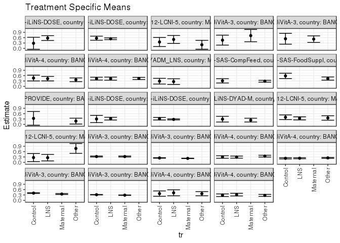

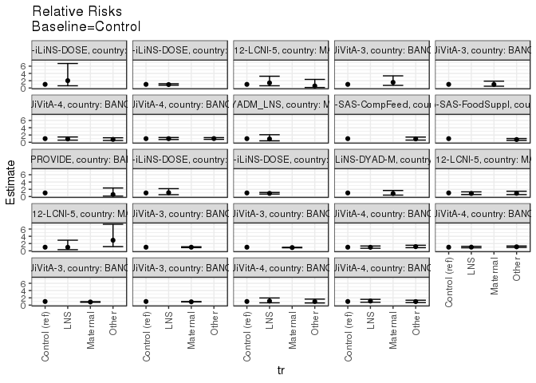

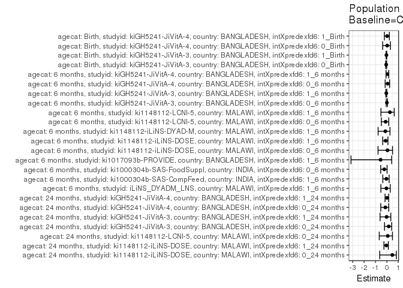

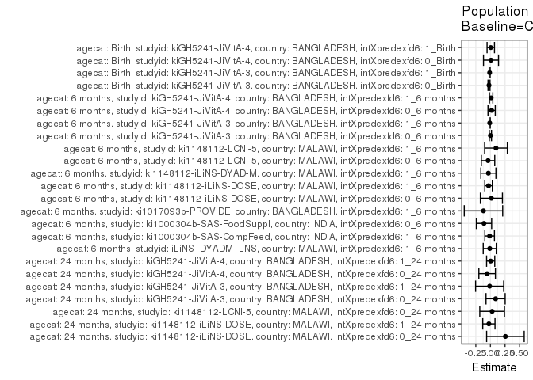

## Results Table

### Parameter: TSM

| agecat | studyid | country | intXpredexfd6 | intervention_level | baseline_level | estimate | ci_lower | ci_upper |
| --- | --- | --- | --- | --- | --- | --- | --- | --- |
| Birth | kiGH5241-JiVitA-3 | BANGLADESH | 0_Birth | Control | NA | 0.4034840 | 0.3809444 | 0.4260236 |
| Birth | kiGH5241-JiVitA-3 | BANGLADESH | 0_Birth | Maternal | NA | 0.3512352 | 0.3233783 | 0.3790922 |
| Birth | kiGH5241-JiVitA-3 | BANGLADESH | 1_Birth | Control | NA | 0.3135789 | 0.3014129 | 0.3257449 |
| Birth | kiGH5241-JiVitA-3 | BANGLADESH | 1_Birth | Maternal | NA | 0.2873756 | 0.2755561 | 0.2991952 |
| Birth | kiGH5241-JiVitA-4 | BANGLADESH | 0_Birth | Control | NA | 0.3750000 | 0.2270859 | 0.5229141 |
| Birth | kiGH5241-JiVitA-4 | BANGLADESH | 0_Birth | LNS | NA | 0.4210526 | 0.2524572 | 0.5896480 |
| Birth | kiGH5241-JiVitA-4 | BANGLADESH | 0_Birth | Other | NA | 0.3714286 | 0.2543774 | 0.4884797 |
| Birth | kiGH5241-JiVitA-4 | BANGLADESH | 1_Birth | Control | NA | 0.2848485 | 0.2116311 | 0.3580658 |
| Birth | kiGH5241-JiVitA-4 | BANGLADESH | 1_Birth | LNS | NA | 0.3181818 | 0.2410489 | 0.3953147 |
| Birth | kiGH5241-JiVitA-4 | BANGLADESH | 1_Birth | Other | NA | 0.2769784 | 0.2204503 | 0.3335066 |
| 6 months | iLiNS_DYADM_LNS | MALAWI | 1_6 months | Control | NA | 0.2903226 | 0.1292107 | 0.4514344 |
| 6 months | iLiNS_DYADM_LNS | MALAWI | 1_6 months | LNS | NA | 0.2666667 | 0.1071111 | 0.4262222 |
| 6 months | ki1000304b-SAS-CompFeed | INDIA | 1_6 months | Control | NA | 0.3092784 | 0.1900328 | 0.4285239 |
| 6 months | ki1000304b-SAS-CompFeed | INDIA | 1_6 months | Other | NA | 0.2875000 | 0.2339413 | 0.3410587 |
| 6 months | ki1000304b-SAS-FoodSuppl | INDIA | 0_6 months | Control | NA | 0.5853659 | 0.4340920 | 0.7366397 |
| 6 months | ki1000304b-SAS-FoodSuppl | INDIA | 0_6 months | Other | NA | 0.4369748 | 0.3475767 | 0.5263729 |
| 6 months | ki1017093b-PROVIDE | BANGLADESH | 1_6 months | Control | NA | 0.3333333 | -0.0507835 | 0.7174502 |
| 6 months | ki1017093b-PROVIDE | BANGLADESH | 1_6 months | Other | NA | 0.1818182 | 0.0176922 | 0.3459442 |
| 6 months | ki1148112-iLiNS-DOSE | MALAWI | 0_6 months | Control | NA | 0.3000000 | 0.0985368 | 0.5014632 |
| 6 months | ki1148112-iLiNS-DOSE | MALAWI | 0_6 months | LNS | NA | 0.3191489 | 0.2419673 | 0.3963306 |
| 6 months | ki1148112-iLiNS-DOSE | MALAWI | 1_6 months | Control | NA | 0.3151515 | 0.2442301 | 0.3860729 |
| 6 months | ki1148112-iLiNS-DOSE | MALAWI | 1_6 months | LNS | NA | 0.2767962 | 0.2466857 | 0.3069068 |
| 6 months | ki1148112-iLiNS-DYAD-M | MALAWI | 1_6 months | Control | NA | 0.2903226 | 0.1296800 | 0.4509651 |
| 6 months | ki1148112-iLiNS-DYAD-M | MALAWI | 1_6 months | Maternal | NA | 0.2380952 | 0.1323585 | 0.3438320 |
| 6 months | ki1148112-LCNI-5 | MALAWI | 0_6 months | Control | NA | 0.3962264 | 0.2642531 | 0.5281997 |
| 6 months | ki1148112-LCNI-5 | MALAWI | 0_6 months | LNS | NA | 0.3362069 | 0.2500468 | 0.4223670 |
| 6 months | ki1148112-LCNI-5 | MALAWI | 0_6 months | Other | NA | 0.3571429 | 0.2313663 | 0.4829194 |
| 6 months | ki1148112-LCNI-5 | MALAWI | 1_6 months | Control | NA | 0.2666667 | 0.0404589 | 0.4928745 |
| 6 months | ki1148112-LCNI-5 | MALAWI | 1_6 months | LNS | NA | 0.2608696 | 0.0794741 | 0.4422650 |
| 6 months | ki1148112-LCNI-5 | MALAWI | 1_6 months | Other | NA | 0.7777778 | 0.5032297 | 1.0523258 |
| 6 months | kiGH5241-JiVitA-3 | BANGLADESH | 0_6 months | Control | NA | 0.3240950 | 0.2973351 | 0.3508549 |
| 6 months | kiGH5241-JiVitA-3 | BANGLADESH | 0_6 months | Maternal | NA | 0.3230676 | 0.2951111 | 0.3510242 |
| 6 months | kiGH5241-JiVitA-3 | BANGLADESH | 1_6 months | Control | NA | 0.2440872 | 0.2306004 | 0.2575740 |
| 6 months | kiGH5241-JiVitA-3 | BANGLADESH | 1_6 months | Maternal | NA | 0.2202611 | 0.2080748 | 0.2324473 |
| 6 months | kiGH5241-JiVitA-4 | BANGLADESH | 0_6 months | Control | NA | 0.2990654 | 0.2273176 | 0.3708133 |
| 6 months | kiGH5241-JiVitA-4 | BANGLADESH | 0_6 months | LNS | NA | 0.2914980 | 0.2333439 | 0.3496520 |
| 6 months | kiGH5241-JiVitA-4 | BANGLADESH | 0_6 months | Other | NA | 0.3455378 | 0.2941389 | 0.3969367 |
| 6 months | kiGH5241-JiVitA-4 | BANGLADESH | 1_6 months | Control | NA | 0.2255814 | 0.1917254 | 0.2594373 |
| 6 months | kiGH5241-JiVitA-4 | BANGLADESH | 1_6 months | LNS | NA | 0.2299349 | 0.2009727 | 0.2588972 |
| 6 months | kiGH5241-JiVitA-4 | BANGLADESH | 1_6 months | Other | NA | 0.2490298 | 0.2230171 | 0.2750424 |
| 24 months | ki1148112-iLiNS-DOSE | MALAWI | 0_24 months | Control | NA | 0.2857143 | -0.0518162 | 0.6232448 |
| 24 months | ki1148112-iLiNS-DOSE | MALAWI | 0_24 months | LNS | NA | 0.5769231 | 0.4414893 | 0.7123569 |
| 24 months | ki1148112-iLiNS-DOSE | MALAWI | 1_24 months | Control | NA | 0.5694444 | 0.4549422 | 0.6839467 |
| 24 months | ki1148112-iLiNS-DOSE | MALAWI | 1_24 months | LNS | NA | 0.5378378 | 0.4869795 | 0.5886961 |
| 24 months | ki1148112-LCNI-5 | MALAWI | 0_24 months | Control | NA | 0.3571429 | 0.1032477 | 0.6110380 |
| 24 months | ki1148112-LCNI-5 | MALAWI | 0_24 months | LNS | NA | 0.5000000 | 0.2783360 | 0.7216640 |
| 24 months | ki1148112-LCNI-5 | MALAWI | 0_24 months | Other | NA | 0.2000000 | -0.0507842 | 0.4507842 |
| 24 months | kiGH5241-JiVitA-3 | BANGLADESH | 0_24 months | Control | NA | 0.4615385 | 0.1835057 | 0.7395712 |
| 24 months | kiGH5241-JiVitA-3 | BANGLADESH | 0_24 months | Maternal | NA | 0.7142857 | 0.3709340 | 1.0576374 |
| 24 months | kiGH5241-JiVitA-3 | BANGLADESH | 1_24 months | Control | NA | 0.5384615 | 0.2330873 | 0.8438358 |
| 24 months | kiGH5241-JiVitA-3 | BANGLADESH | 1_24 months | Maternal | NA | 0.5185185 | 0.3356023 | 0.7014348 |
| 24 months | kiGH5241-JiVitA-4 | BANGLADESH | 0_24 months | Control | NA | 0.4651163 | 0.3028706 | 0.6273620 |
| 24 months | kiGH5241-JiVitA-4 | BANGLADESH | 0_24 months | LNS | NA | 0.4307692 | 0.3056746 | 0.5558638 |
| 24 months | kiGH5241-JiVitA-4 | BANGLADESH | 0_24 months | Other | NA | 0.3666667 | 0.2620154 | 0.4713180 |
| 24 months | kiGH5241-JiVitA-4 | BANGLADESH | 1_24 months | Control | NA | 0.4325843 | 0.3519158 | 0.5132527 |
| 24 months | kiGH5241-JiVitA-4 | BANGLADESH | 1_24 months | LNS | NA | 0.4310345 | 0.3443701 | 0.5176988 |
| 24 months | kiGH5241-JiVitA-4 | BANGLADESH | 1_24 months | Other | NA | 0.4426752 | 0.3802475 | 0.5051028 |

### Parameter: E(Y)

| agecat | studyid | country | intXpredexfd6 | intervention_level | baseline_level | estimate | ci_lower | ci_upper |
| --- | --- | --- | --- | --- | --- | --- | --- | --- |
| Birth | kiGH5241-JiVitA-3 | BANGLADESH | 0_Birth | NA | NA | 0.3790768 | 0.3612523 | 0.3969013 |
| Birth | kiGH5241-JiVitA-3 | BANGLADESH | 1_Birth | NA | NA | 0.3001457 | 0.2915966 | 0.3086949 |
| Birth | kiGH5241-JiVitA-4 | BANGLADESH | 0_Birth | NA | NA | 0.3851351 | 0.3041471 | 0.4661232 |
| Birth | kiGH5241-JiVitA-4 | BANGLADESH | 1_Birth | NA | NA | 0.2907916 | 0.2518865 | 0.3296967 |
| 6 months | iLiNS_DYADM_LNS | MALAWI | 1_6 months | NA | NA | 0.2786885 | 0.1652414 | 0.3921356 |
| 6 months | ki1000304b-SAS-CompFeed | INDIA | 1_6 months | NA | NA | 0.2957198 | 0.2395510 | 0.3518887 |
| 6 months | ki1000304b-SAS-FoodSuppl | INDIA | 0_6 months | NA | NA | 0.4750000 | 0.3973796 | 0.5526204 |
| 6 months | ki1017093b-PROVIDE | BANGLADESH | 1_6 months | NA | NA | 0.2142857 | 0.0595127 | 0.3690587 |
| 6 months | ki1148112-iLiNS-DOSE | MALAWI | 0_6 months | NA | NA | 0.3167702 | 0.2446854 | 0.3888550 |
| 6 months | ki1148112-iLiNS-DOSE | MALAWI | 1_6 months | NA | NA | 0.2830375 | 0.2552970 | 0.3107779 |
| 6 months | ki1148112-iLiNS-DYAD-M | MALAWI | 1_6 months | NA | NA | 0.2553191 | 0.1666988 | 0.3439395 |
| 6 months | ki1148112-LCNI-5 | MALAWI | 0_6 months | NA | NA | 0.3555556 | 0.2928696 | 0.4182416 |
| 6 months | ki1148112-LCNI-5 | MALAWI | 1_6 months | NA | NA | 0.3617021 | 0.2228488 | 0.5005555 |
| 6 months | kiGH5241-JiVitA-3 | BANGLADESH | 0_6 months | NA | NA | 0.3235981 | 0.3042651 | 0.3429312 |
| 6 months | kiGH5241-JiVitA-3 | BANGLADESH | 1_6 months | NA | NA | 0.2319279 | 0.2228159 | 0.2410400 |
| 6 months | kiGH5241-JiVitA-4 | BANGLADESH | 0_6 months | NA | NA | 0.3195991 | 0.2851973 | 0.3540009 |
| 6 months | kiGH5241-JiVitA-4 | BANGLADESH | 1_6 months | NA | NA | 0.2376803 | 0.2206903 | 0.2546703 |
| 24 months | ki1148112-iLiNS-DOSE | MALAWI | 0_24 months | NA | NA | 0.5423729 | 0.4141578 | 0.6705879 |
| 24 months | ki1148112-iLiNS-DOSE | MALAWI | 1_24 months | NA | NA | 0.5429864 | 0.4964934 | 0.5894795 |
| 24 months | ki1148112-LCNI-5 | MALAWI | 0_24 months | NA | NA | 0.3863636 | 0.2408286 | 0.5318987 |
| 24 months | kiGH5241-JiVitA-3 | BANGLADESH | 0_24 months | NA | NA | 0.5500000 | 0.3263037 | 0.7736963 |
| 24 months | kiGH5241-JiVitA-3 | BANGLADESH | 1_24 months | NA | NA | 0.5250000 | 0.3666127 | 0.6833873 |
| 24 months | kiGH5241-JiVitA-4 | BANGLADESH | 0_24 months | NA | NA | 0.4090909 | 0.3365982 | 0.4815837 |
| 24 months | kiGH5241-JiVitA-4 | BANGLADESH | 1_24 months | NA | NA | 0.4369369 | 0.3939807 | 0.4798931 |

### Parameter: RR

| agecat | studyid | country | intXpredexfd6 | intervention_level | baseline_level | estimate | ci_lower | ci_upper |
| --- | --- | --- | --- | --- | --- | --- | --- | --- |
| Birth | kiGH5241-JiVitA-3 | BANGLADESH | 0_Birth | Control | Control | 1.0000000 | 1.0000000 | 1.0000000 |
| Birth | kiGH5241-JiVitA-3 | BANGLADESH | 0_Birth | Maternal | Control | 0.8705060 | 0.7900203 | 0.9591913 |
| Birth | kiGH5241-JiVitA-3 | BANGLADESH | 1_Birth | Control | Control | 1.0000000 | 1.0000000 | 1.0000000 |
| Birth | kiGH5241-JiVitA-3 | BANGLADESH | 1_Birth | Maternal | Control | 0.9164380 | 0.8660504 | 0.9697572 |
| Birth | kiGH5241-JiVitA-4 | BANGLADESH | 0_Birth | Control | Control | 1.0000000 | 1.0000000 | 1.0000000 |
| Birth | kiGH5241-JiVitA-4 | BANGLADESH | 0_Birth | LNS | Control | 1.1228070 | 0.6400633 | 1.9696420 |
| Birth | kiGH5241-JiVitA-4 | BANGLADESH | 0_Birth | Other | Control | 0.9904762 | 0.5978764 | 1.6408795 |
| Birth | kiGH5241-JiVitA-4 | BANGLADESH | 1_Birth | Control | Control | 1.0000000 | 1.0000000 | 1.0000000 |
| Birth | kiGH5241-JiVitA-4 | BANGLADESH | 1_Birth | LNS | Control | 1.1170213 | 0.7845663 | 1.5903518 |
| Birth | kiGH5241-JiVitA-4 | BANGLADESH | 1_Birth | Other | Control | 0.9723710 | 0.7002624 | 1.3502160 |
| 6 months | iLiNS_DYADM_LNS | MALAWI | 1_6 months | Control | Control | 1.0000000 | 1.0000000 | 1.0000000 |
| 6 months | iLiNS_DYADM_LNS | MALAWI | 1_6 months | LNS | Control | 0.9185185 | 0.4061397 | 2.0773056 |
| 6 months | ki1000304b-SAS-CompFeed | INDIA | 1_6 months | Control | Control | 1.0000000 | 1.0000000 | 1.0000000 |
| 6 months | ki1000304b-SAS-CompFeed | INDIA | 1_6 months | Other | Control | 0.9295833 | 0.6059180 | 1.4261421 |
| 6 months | ki1000304b-SAS-FoodSuppl | INDIA | 0_6 months | Control | Control | 1.0000000 | 1.0000000 | 1.0000000 |
| 6 months | ki1000304b-SAS-FoodSuppl | INDIA | 0_6 months | Other | Control | 0.7464986 | 0.5368882 | 1.0379445 |
| 6 months | ki1017093b-PROVIDE | BANGLADESH | 1_6 months | Control | Control | 1.0000000 | 1.0000000 | 1.0000000 |
| 6 months | ki1017093b-PROVIDE | BANGLADESH | 1_6 months | Other | Control | 0.5454545 | 0.1261915 | 2.3576925 |
| 6 months | ki1148112-iLiNS-DOSE | MALAWI | 0_6 months | Control | Control | 1.0000000 | 1.0000000 | 1.0000000 |
| 6 months | ki1148112-iLiNS-DOSE | MALAWI | 0_6 months | LNS | Control | 1.0638298 | 0.5210619 | 2.1719756 |
| 6 months | ki1148112-iLiNS-DOSE | MALAWI | 1_6 months | Control | Control | 1.0000000 | 1.0000000 | 1.0000000 |
| 6 months | ki1148112-iLiNS-DOSE | MALAWI | 1_6 months | LNS | Control | 0.8782957 | 0.6840500 | 1.1277004 |
| 6 months | ki1148112-iLiNS-DYAD-M | MALAWI | 1_6 months | Control | Control | 1.0000000 | 1.0000000 | 1.0000000 |
| 6 months | ki1148112-iLiNS-DYAD-M | MALAWI | 1_6 months | Maternal | Control | 0.8201058 | 0.4034027 | 1.6672512 |
| 6 months | ki1148112-LCNI-5 | MALAWI | 0_6 months | Control | Control | 1.0000000 | 1.0000000 | 1.0000000 |
| 6 months | ki1148112-LCNI-5 | MALAWI | 0_6 months | LNS | Control | 0.8485222 | 0.5573767 | 1.2917473 |
| 6 months | ki1148112-LCNI-5 | MALAWI | 0_6 months | Other | Control | 0.9013605 | 0.5551134 | 1.4635763 |
| 6 months | ki1148112-LCNI-5 | MALAWI | 1_6 months | Control | Control | 1.0000000 | 1.0000000 | 1.0000000 |
| 6 months | ki1148112-LCNI-5 | MALAWI | 1_6 months | LNS | Control | 0.9782609 | 0.3266609 | 2.9296264 |
| 6 months | ki1148112-LCNI-5 | MALAWI | 1_6 months | Other | Control | 2.9166667 | 1.1637515 | 7.3099321 |
| 6 months | kiGH5241-JiVitA-3 | BANGLADESH | 0_6 months | Control | Control | 1.0000000 | 1.0000000 | 1.0000000 |
| 6 months | kiGH5241-JiVitA-3 | BANGLADESH | 0_6 months | Maternal | Control | 0.9968300 | 0.8844630 | 1.1234727 |
| 6 months | kiGH5241-JiVitA-3 | BANGLADESH | 1_6 months | Control | Control | 1.0000000 | 1.0000000 | 1.0000000 |
| 6 months | kiGH5241-JiVitA-3 | BANGLADESH | 1_6 months | Maternal | Control | 0.9023868 | 0.8344972 | 0.9757994 |
| 6 months | kiGH5241-JiVitA-4 | BANGLADESH | 0_6 months | Control | Control | 1.0000000 | 1.0000000 | 1.0000000 |
| 6 months | kiGH5241-JiVitA-4 | BANGLADESH | 0_6 months | LNS | Control | 0.9746964 | 0.7132826 | 1.3319167 |
| 6 months | kiGH5241-JiVitA-4 | BANGLADESH | 0_6 months | Other | Control | 1.1553919 | 0.8712120 | 1.5322682 |
| 6 months | kiGH5241-JiVitA-4 | BANGLADESH | 1_6 months | Control | Control | 1.0000000 | 1.0000000 | 1.0000000 |
| 6 months | kiGH5241-JiVitA-4 | BANGLADESH | 1_6 months | LNS | Control | 1.0192991 | 0.8378447 | 1.2400517 |
| 6 months | kiGH5241-JiVitA-4 | BANGLADESH | 1_6 months | Other | Control | 1.1039463 | 0.9194784 | 1.3254226 |
| 24 months | ki1148112-iLiNS-DOSE | MALAWI | 0_24 months | Control | Control | 1.0000000 | 1.0000000 | 1.0000000 |
| 24 months | ki1148112-iLiNS-DOSE | MALAWI | 0_24 months | LNS | Control | 2.0192308 | 0.6054771 | 6.7340169 |
| 24 months | ki1148112-iLiNS-DOSE | MALAWI | 1_24 months | Control | Control | 1.0000000 | 1.0000000 | 1.0000000 |
| 24 months | ki1148112-iLiNS-DOSE | MALAWI | 1_24 months | LNS | Control | 0.9444957 | 0.7563084 | 1.1795085 |
| 24 months | ki1148112-LCNI-5 | MALAWI | 0_24 months | Control | Control | 1.0000000 | 1.0000000 | 1.0000000 |
| 24 months | ki1148112-LCNI-5 | MALAWI | 0_24 months | LNS | Control | 1.4000000 | 0.6057191 | 3.2358236 |
| 24 months | ki1148112-LCNI-5 | MALAWI | 0_24 months | Other | Control | 0.5600000 | 0.1324906 | 2.3669601 |
| 24 months | kiGH5241-JiVitA-3 | BANGLADESH | 0_24 months | Control | Control | 1.0000000 | 1.0000000 | 1.0000000 |
| 24 months | kiGH5241-JiVitA-3 | BANGLADESH | 0_24 months | Maternal | Control | 1.5476190 | 0.7160769 | 3.3447872 |
| 24 months | kiGH5241-JiVitA-3 | BANGLADESH | 1_24 months | Control | Control | 1.0000000 | 1.0000000 | 1.0000000 |
| 24 months | kiGH5241-JiVitA-3 | BANGLADESH | 1_24 months | Maternal | Control | 0.9629630 | 0.4937984 | 1.8778871 |
| 24 months | kiGH5241-JiVitA-4 | BANGLADESH | 0_24 months | Control | Control | 1.0000000 | 1.0000000 | 1.0000000 |
| 24 months | kiGH5241-JiVitA-4 | BANGLADESH | 0_24 months | LNS | Control | 0.9261538 | 0.5883840 | 1.4578250 |
| 24 months | kiGH5241-JiVitA-4 | BANGLADESH | 0_24 months | Other | Control | 0.7883333 | 0.5023638 | 1.2370905 |
| 24 months | kiGH5241-JiVitA-4 | BANGLADESH | 1_24 months | Control | Control | 1.0000000 | 1.0000000 | 1.0000000 |
| 24 months | kiGH5241-JiVitA-4 | BANGLADESH | 1_24 months | LNS | Control | 0.9964174 | 0.7574078 | 1.3108494 |
| 24 months | kiGH5241-JiVitA-4 | BANGLADESH | 1_24 months | Other | Control | 1.0233270 | 0.8100031 | 1.2928322 |

### Parameter: PAR

| agecat | studyid | country | intXpredexfd6 | intervention_level | baseline_level | estimate | ci_lower | ci_upper |
| --- | --- | --- | --- | --- | --- | --- | --- | --- |
| Birth | kiGH5241-JiVitA-3 | BANGLADESH | 0_Birth | Control | NA | -0.0244072 | -0.0413136 | -0.0075009 |
| Birth | kiGH5241-JiVitA-3 | BANGLADESH | 1_Birth | Control | NA | -0.0134332 | -0.0222235 | -0.0046428 |
| Birth | kiGH5241-JiVitA-4 | BANGLADESH | 0_Birth | Control | NA | 0.0101351 | -0.1186353 | 0.1389056 |
| Birth | kiGH5241-JiVitA-4 | BANGLADESH | 1_Birth | Control | NA | 0.0059431 | -0.0574285 | 0.0693148 |
| 6 months | iLiNS_DYADM_LNS | MALAWI | 1_6 months | Control | NA | -0.0116341 | -0.1231900 | 0.0999219 |
| 6 months | ki1000304b-SAS-CompFeed | INDIA | 1_6 months | Control | NA | -0.0135585 | -0.0956081 | 0.0684910 |
| 6 months | ki1000304b-SAS-FoodSuppl | INDIA | 0_6 months | Control | NA | -0.1103659 | -0.2414413 | 0.0207096 |
| 6 months | ki1017093b-PROVIDE | BANGLADESH | 1_6 months | Control | NA | -0.1190476 | -0.4480864 | 0.2099912 |
| 6 months | ki1148112-iLiNS-DOSE | MALAWI | 0_6 months | Control | NA | 0.0167702 | -0.1721737 | 0.2057141 |
| 6 months | ki1148112-iLiNS-DOSE | MALAWI | 1_6 months | Control | NA | -0.0321140 | -0.0966311 | 0.0324030 |
| 6 months | ki1148112-iLiNS-DYAD-M | MALAWI | 1_6 months | Control | NA | -0.0350034 | -0.1639941 | 0.0939872 |
| 6 months | ki1148112-LCNI-5 | MALAWI | 0_6 months | Control | NA | -0.0406709 | -0.1553058 | 0.0739641 |
| 6 months | ki1148112-LCNI-5 | MALAWI | 1_6 months | Control | NA | 0.0950355 | -0.0993573 | 0.2894282 |
| 6 months | kiGH5241-JiVitA-3 | BANGLADESH | 0_6 months | Control | NA | -0.0004969 | -0.0192127 | 0.0182189 |
| 6 months | kiGH5241-JiVitA-3 | BANGLADESH | 1_6 months | Control | NA | -0.0121592 | -0.0215198 | -0.0027987 |
| 6 months | kiGH5241-JiVitA-4 | BANGLADESH | 0_6 months | Control | NA | 0.0205337 | -0.0417193 | 0.0827866 |
| 6 months | kiGH5241-JiVitA-4 | BANGLADESH | 1_6 months | Control | NA | 0.0120989 | -0.0168901 | 0.0410879 |
| 24 months | ki1148112-iLiNS-DOSE | MALAWI | 0_24 months | Control | NA | 0.2566586 | -0.0647951 | 0.5781123 |
| 24 months | ki1148112-iLiNS-DOSE | MALAWI | 1_24 months | Control | NA | -0.0264580 | -0.1313436 | 0.0784276 |
| 24 months | ki1148112-LCNI-5 | MALAWI | 0_24 months | Control | NA | 0.0292208 | -0.1820171 | 0.2404587 |
| 24 months | kiGH5241-JiVitA-3 | BANGLADESH | 0_24 months | Control | NA | 0.0884615 | -0.0753963 | 0.2523194 |
| 24 months | kiGH5241-JiVitA-3 | BANGLADESH | 1_24 months | Control | NA | -0.0134615 | -0.2537223 | 0.2267992 |
| 24 months | kiGH5241-JiVitA-4 | BANGLADESH | 0_24 months | Control | NA | -0.0560254 | -0.1975475 | 0.0854968 |
| 24 months | kiGH5241-JiVitA-4 | BANGLADESH | 1_24 months | Control | NA | 0.0043527 | -0.0654478 | 0.0741531 |

### Parameter: PAF

| agecat | studyid | country | intXpredexfd6 | intervention_level | baseline_level | estimate | ci_lower | ci_upper |
| --- | --- | --- | --- | --- | --- | --- | --- | --- |
| Birth | kiGH5241-JiVitA-3 | BANGLADESH | 0_Birth | Control | NA | -0.0643860 | -0.1105359 | -0.0201539 |
| Birth | kiGH5241-JiVitA-3 | BANGLADESH | 1_Birth | Control | NA | -0.0447555 | -0.0745057 | -0.0158290 |
| Birth | kiGH5241-JiVitA-4 | BANGLADESH | 0_Birth | Control | NA | 0.0263158 | -0.3722101 | 0.3090993 |
| Birth | kiGH5241-JiVitA-4 | BANGLADESH | 1_Birth | Control | NA | 0.0204377 | -0.2235390 | 0.2157648 |
| 6 months | iLiNS_DYADM_LNS | MALAWI | 1_6 months | Control | NA | -0.0417457 | -0.5297105 | 0.2905624 |
| 6 months | ki1000304b-SAS-CompFeed | INDIA | 1_6 months | Control | NA | -0.0458492 | -0.3584062 | 0.1947913 |
| 6 months | ki1000304b-SAS-FoodSuppl | INDIA | 0_6 months | Control | NA | -0.2323492 | -0.5456350 | 0.0174365 |
| 6 months | ki1017093b-PROVIDE | BANGLADESH | 1_6 months | Control | NA | -0.5555556 | -3.1529922 | 0.4173471 |
| 6 months | ki1148112-iLiNS-DOSE | MALAWI | 0_6 months | Control | NA | 0.0529412 | -0.7778474 | 0.4955020 |
| 6 months | ki1148112-iLiNS-DOSE | MALAWI | 1_6 months | Control | NA | -0.1134621 | -0.3663764 | 0.0926380 |
| 6 months | ki1148112-iLiNS-DYAD-M | MALAWI | 1_6 months | Control | NA | -0.1370968 | -0.7724189 | 0.2704946 |
| 6 months | ki1148112-LCNI-5 | MALAWI | 0_6 months | Control | NA | -0.1143868 | -0.4884734 | 0.1656835 |
| 6 months | ki1148112-LCNI-5 | MALAWI | 1_6 months | Control | NA | 0.2627451 | -0.5250649 | 0.6435924 |
| 6 months | kiGH5241-JiVitA-3 | BANGLADESH | 0_6 months | Control | NA | -0.0015355 | -0.0610758 | 0.0546637 |
| 6 months | kiGH5241-JiVitA-3 | BANGLADESH | 1_6 months | Control | NA | -0.0524268 | -0.0934841 | -0.0129111 |
| 6 months | kiGH5241-JiVitA-4 | BANGLADESH | 0_6 months | Control | NA | 0.0642483 | -0.1526199 | 0.2403122 |
| 6 months | kiGH5241-JiVitA-4 | BANGLADESH | 1_6 months | Control | NA | 0.0509041 | -0.0793797 | 0.1654623 |
| 24 months | ki1148112-iLiNS-DOSE | MALAWI | 0_24 months | Control | NA | 0.4732143 | -0.6308463 | 0.8298410 |
| 24 months | ki1148112-iLiNS-DOSE | MALAWI | 1_24 months | Control | NA | -0.0487269 | -0.2609057 | 0.1277476 |
| 24 months | ki1148112-LCNI-5 | MALAWI | 0_24 months | Control | NA | 0.0756303 | -0.6702188 | 0.4884147 |
| 24 months | kiGH5241-JiVitA-3 | BANGLADESH | 0_24 months | Control | NA | 0.1608392 | -0.2075079 | 0.4168229 |
| 24 months | kiGH5241-JiVitA-3 | BANGLADESH | 1_24 months | Control | NA | -0.0256410 | -0.6008654 | 0.3428932 |
| 24 months | kiGH5241-JiVitA-4 | BANGLADESH | 0_24 months | Control | NA | -0.1369509 | -0.5407808 | 0.1610374 |
| 24 months | kiGH5241-JiVitA-4 | BANGLADESH | 1_24 months | Control | NA | 0.0099618 | -0.1633613 | 0.1574624 |